# Impact of Subgroup Misclassification on Detecting Heterogeneous Treatment Effects in *Staphylococcus aureus* Bacteremia: A Simulation Study

Author

Fergus Hamilton

## Introduction

*Staphylococcus aureus* bacteremia (SAB) is a serious infection characterized by significant clinical heterogeneity in patient presentation, disease course, and outcomes. Recent research by Swets, Russell, et al. (Clinical Infectious Diseases, 2024) identified five distinct clinical subphenotypes within SAB using latent class analysis on data from observational and trial cohorts (Edinburgh, ARREST, SAFO).

Crucially, a secondary analysis of the ARREST trial (Adjunctive Rifampicin for *S. aureus* Bacteraemia) suggested differential treatment effects of adjunctive rifampicin across these subphenotypes. Specifically, rifampicin was associated with increased 84-day mortality in subphenotype B (Nosocomial IV catheter-associated SAB; OR 18.8) and improved microbiologic outcomes in subphenotype C (Community-acquired metastatic SAB; OR 0.17).

This finding raises a critical question for both clinical trial design and potential future stratified treatment approaches: If such treatment effect heterogeneity exists, how accurately must patients be classified into these subphenotypes to reliably detect these differences and avoid misleading conclusions? Misclassification is inevitable with any diagnostic or predictive tool, and understanding its impact is essential.

This simulation study aims to address this question by:

1. Estimating the sample sizes required to detect the subgroup-specific treatment effects observed by Russell et al. with adequate statistical power, assuming perfect patient classification **when analyzing subgroups within a trial of the general population (post-hoc analysis)**.
2. Quantifying the impact of varying levels of classification accuracy on statistical power, estimation bias (Mean Squared Error), and the probability of estimating effects in the wrong direction for both subgroup-specific and overall treatment effects **when analyzing subgroups within a trial of the general population (post-hoc analysis)**.
3. Estimating the Number Needed to Screen (`NNS_enrich`) and the resulting average Number Needed to Randomize (`NNR_enrich`) to achieve adequate power in an **enrichment trial** targeting specific subgroups, using a test with varying accuracy.

## Methods

### Simulation Model

We developed a simulation model based on the functions defined in `code/functions/functions.R` and helper functions defined herein. The core steps for each simulation run vary by Aim:

1. **Data Generation (`simulate_trial_data`):** Simulate individual patient data for a hypothetical two-arm (treatment vs. control) trial of size `n`. Patients are assigned a ‘true’ subgroup (A-E) based on specified frequencies. Treatment is assigned randomly (50/50). An outcome (‘success’, e.g., death by 84 days, coded as 1) is generated for each patient based on their true subgroup, treatment assignment, the subgroup-specific baseline event probability (`p0`), and the subgroup-specific treatment effect (odds ratio, `or_vector`).
2. **Misclassification / Testing (`misclassify_group`):**
   - Aim 1: Assumes perfect classification (accuracy=1.0). Analysis is on true subgroups (implicitly done by `estimate_effect_misclassify` in `replicate_sims` when accuracy=1.0).
   - Aim 2: An ‘assigned’ subgroup is determined post-hoc based on `accuracy` using `misclassify_group` (implicitly called by `estimate_effect_misclassify` in `replicate_sims`). Analysis is on assigned subgroups.
   - Aim 3: A large cohort is simulated (`n_screened`). An ‘assigned’ subgroup (test result) is determined for each based on `accuracy` using the internally defined `misclassify_group`. Patients where `assigned_group == target_group` form the `randomized_cohort`. Analysis is on this cohort.
3. **Effect Estimation (`estimate_effect_misclassify` / `fit_glm_safe`):** Logistic regression (`glm(success ~ treatment, family = binomial)`) is performed. For Aim 2, this is done for each *assigned* subgroup and overall (handled by `estimate_effect_misclassify` in `replicate_sims`). For Aim 1, it’s done post-hoc on true subgroups (handled by `estimate_effect_misclassify` in `replicate_sims` with accuracy=1.0). For Aim 3, it’s done on the `randomized_cohort` using `fit_glm_safe`. The estimated log odds ratio (beta), standard error (se), and p-value for the treatment effect are extracted.

### Parameterization

The simulation parameters were chosen to reflect the findings from the Russell et al. analysis of the ARREST trial data, specifically focusing on the 84-day mortality outcome with adjunctive rifampicin vs. placebo.

- **Treatment Effects (Odds Ratios):** The ‘true’ underlying ORs for the treatment (rifampicin) effect on 84-day mortality (success=1) compared to control (placebo) within each subgroup were set based on the point estimates reported:
  - `or_vector <- c(A = 1.0, B = 18.8, C = 0.79, D = 1.4, E = 0.3)`
  - *Note: The OR for subgroup C (0.79) used here relates to 84-day mortality, distinct from the OR of 0.17 for microbiologic outcomes mentioned in the Introduction.*
- **Subgroup Frequencies (Population Prevalence):** The proportions of patients in each subgroup were based on the distribution observed in the ARREST placebo arm (n=388):
  - `freq_vector <- c(A = 60/388, B = 52/388, C = 138/388, D = 69/388, E = 69/388)`
- **Baseline Event Rates (p0):** The baseline probability of the outcome (death by 84 days) in the *control* group for each subgroup was estimated from the ARREST placebo arm:
  - `p0_vector <- c(A = 7/60, B = 0/52, C = 11/138, D = 11/69, E = 1/69)`
  - `n0_B <- 52` # Number in control group for subgroup B in ARREST placebo arm
  - `p0_B_corrected <- 0.5 / (n0_B + 0.5)` # Haldane-Anscombe correction for zero events
  - `p0_vector_adjusted <- p0_vector`
  - `p0_vector_adjusted["B"] <- p0_B_corrected` # Use corrected p0 for subgroup B (~0.0095)

### Analysis

Simulation results were aggregated across repetitions; summarized with descriptive tables (`gt`) and plots (`ggplot2`). Power is defined as the proportion of simulations where the p-value for the treatment effect was statistically significant (p < alpha). Bias is the average difference between the estimated log OR and the true log OR (target for the assigned group). MSE is the mean squared error of the log OR estimate against the target log OR. Wrong direction rate is the percentage of simulations where the sign of the estimated log OR differed from the sign of the target log OR.

## Results

```r
or_mortality       <- c(A = 1.0, B = 18.8, C = 0.79, D = 1.4, E = 0.3)
freq_arrest        <- c(A = 60/388, B = 52/388, C = 138/388, D = 69/388, E = 69/388)
p0_arrest_raw      <- c(A = 7/60, B = 0/52, C = 11/138, D = 11/69, E = 1/69)
n0_B <- 52 # N in control group B from ARREST placebo
p0_B_corrected <- 0.5 / (n0_B + 0.5) # Haldane-Anscombe correction
p0_arrest_adjusted <- p0_arrest_raw
p0_arrest_adjusted["B"] <- p0_B_corrected # Use corrected p0 for B (~0.0095)

# Simulation settings
n_reps_global      <- 500 # Final desired number of reps
sample_sizes       <- c(500, 1000, 2000, 3000, 5000, 7500, 10000, 15000, 20000) # For Aim 1
# Define screening sizes for Aim 3 (needs to cover expected NNS)
screen_sizes_aim3  <- c(1000, 2500, 5000, 7500, 10000, 15000, 20000, 30000, 40000, 50000, 75000, 100000, 150000, 200000)
accuracy_levels    <- seq(0.5, 1.0, by = 0.05) # For Aim 2 & Aim 3 test accuracy
n_fixed_aim2       <- 10000 # Sample size for Aim 2
alpha_bonferroni   <- 0.05 / 5
alpha_overall      <- 0.05
alpha_aim3         <- 0.05 # Standard alpha for primary analysis in enrichment trial
target_groups_aim3 <- c("B", "C", "E") # Target groups for enrichment
```

```r
# Display target ORs for ARREST simulation
tibble(
  Subgroup = names(or_mortality),
  `Target OR (Mortality)` = or_mortality
) %>%
  gt() %>%
  tab_header(title = "Target Treatment Effects (ARREST ORs)") %>%
  fmt_number(columns = `Target OR (Mortality)`, decimals = 2)
```

Target Treatment Effects (ARREST ORs)

| Subgroup | Target OR (Mortality) |
| --- | --- |
| A | 1.00 |
| B | 18.80 |
| C | 0.79 |
| D | 1.40 |
| E | 0.30 |

### Aim 1: Sample Size Requirements (Post-Hoc Analysis Power)

This section estimates the statistical power for a *post-hoc* subgroup analysis within a standard trial randomizing the full population mix, assuming perfect classification (`accuracy = 1.0`).

```r
# Run simulations for Aim 1 (No Caching)
# Requires simulate_trial_data and replicate_sims from sourced file
# replicate_sims should internally call estimate_effect_misclassify with accuracy=1.0
results_aim1 <- map_dfr(sample_sizes, ~replicate_sims(
  or_vector  = or_mortality,
  freq_vector = freq_arrest, # Full population mix
  p0_vector  = p0_arrest_adjusted,
  n          = .x, # Total trial size
  accuracy   = 1.0,
  n_reps     = n_reps_global,
  seed       = 1
), .id = "size_id") %>%
  mutate(n_total = sample_sizes[as.numeric(size_id)])

# Calculate power for each subgroup (Bonferroni corrected alpha for post-hoc)
power_aim1 <- results_aim1 %>%
  filter(group != "Overall") %>%
  mutate(pval = as.numeric(pval)) %>%
  group_by(n_total, group) %>%
  summarise(power = mean(pval < alpha_bonferroni, na.rm = TRUE), .groups = "drop")
```

```r
power_aim1 %>%
  mutate(power = scales::percent(power, accuracy = 1)) %>%
  pivot_wider(names_from = group, values_from = power) %>%
  gt() %>%
  cols_label(n_total = "Total Sample Size") %>%
  tab_header(title = "Aim 1: Power for Post-Hoc Subgroup Analysis vs. Total Trial Size (ARREST ORs, Perfect Classification)") %>%
  tab_footnote(footnote = paste("Power calculated at Bonferroni-corrected alpha =", round(alpha_bonferroni, 3))) %>%
  fmt_percent(columns = where(is.character), scale_values = FALSE, decimals = 1)
```

Aim 1: Power for Post-Hoc Subgroup Analysis vs. Total Trial Size (ARREST ORs, Perfect Classification)

| Total Sample Size | A | B | C | D | E |
| --- | --- | --- | --- | --- | --- |
| 500 | 0% | 0% | 0% | 1% | 0% |
| 1000 | 1% | 10% | 1% | 4% | 0% |
| 2000 | 0% | 66% | 4% | 7% | 0% |
| 3000 | 1% | 86% | 4% | 14% | 0% |
| 5000 | 1% | 96% | 9% | 30% | 0% |
| 7500 | 0% | 99% | 15% | 40% | 7% |
| 10000 | 0% | 100% | 24% | 49% | 18% |
| 15000 | 1% | 100% | 39% | 74% | 49% |
| 20000 | 1% | 100% | 51% | 91% | 69% |

Power calculated at Bonferroni-corrected alpha = 0.01

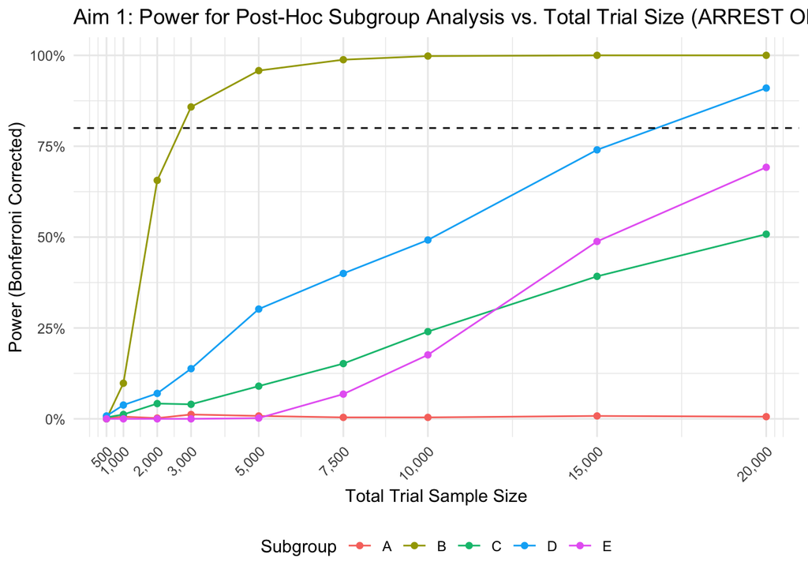

```r
ggplot(power_aim1, aes(x = n_total, y = power, color = group)) +
  geom_line() + geom_point() +
  geom_hline(yintercept = 0.8, linetype = "dashed") +
  scale_x_continuous(breaks = sample_sizes, labels = scales::comma) +
  scale_y_continuous(labels = scales::percent) +
  labs(
    title = "Aim 1: Power for Post-Hoc Subgroup Analysis vs. Total Trial Size (ARREST ORs)",
    x = "Total Trial Sample Size",
    y = "Power (Bonferroni Corrected)",
    color = "Subgroup"
  ) +
  theme(axis.text.x = element_text(angle = 45, hjust = 1))
```

### Aim 2: Impact of Classification Accuracy (Post-Hoc Analysis)

This section assesses the impact of classification accuracy on the results of a *post-hoc* subgroup analysis within a standard trial of fixed size (N = 10^{4}).

```r
# Run simulations for Aim 2 (No Caching)
# Requires simulate_trial_data and replicate_sims from sourced file
# replicate_sims should internally call estimate_effect_misclassify
results_aim2 <- map_dfr(accuracy_levels, ~replicate_sims(
  or_vector  = or_mortality,
  freq_vector = freq_arrest, # Full population mix
  p0_vector  = p0_arrest_adjusted,
  n          = n_fixed_aim2, # Fixed total trial size
  accuracy   = .x,
  n_reps     = n_reps_global,
  seed       = 2
), .id = "acc_id") %>%
  mutate(accuracy = accuracy_levels[as.numeric(acc_id)])

# Define the correct target betas
true_betas_arrest <- tibble(group = names(or_mortality), true_beta_target = log(or_mortality))
true_beta_overall_arrest <- sum(log(or_mortality) * freq_arrest, na.rm = TRUE)
true_betas_arrest <- bind_rows(true_betas_arrest, tibble(group="Overall", true_beta_target = true_beta_overall_arrest))

# Join target betas and calculate per-replicate metrics
# Assumes results_aim2 contains 'beta' and 'pval' from estimate_effect_misclassify output
results_aim2_processed <- results_aim2 %>%
  mutate(beta = as.numeric(beta), pval = as.numeric(pval)) %>%
  left_join(true_betas_arrest, by = "group") %>%
  mutate(
    # Use Bonferroni for subgroups, standard alpha for overall in post-hoc setting
    is_significant = if_else(group == "Overall", pval < alpha_overall, pval < alpha_bonferroni),
    bias_val = beta - true_beta_target,
    mse_val = (beta - true_beta_target)^2,
    wrong_dir_val = if_else(true_beta_target == 0, sign(beta) != 0, sign(beta) != sign(true_beta_target))
  )

# Summarise across replicates
summary_aim2 <- results_aim2_processed %>%
  group_by(accuracy, group) %>%
  summarise(
    power     = mean(is_significant, na.rm = TRUE),
    bias      = mean(bias_val, na.rm = TRUE),
    mse       = mean(mse_val, na.rm = TRUE),
    wrong_dir = mean(wrong_dir_val, na.rm = TRUE) * 100,
    n_reps_successful = sum(!is.na(pval)),
    .groups   = "drop"
  ) %>%
  complete(accuracy, group = c("A", "B", "C", "D", "E", "Overall")) %>%
  arrange(group, accuracy)
```

```r
# Long format GT table for Aim 2 ARREST results
summary_aim2 %>%
  select(
    group,
    accuracy,
    Power = power,
    Bias = bias,
    MSE = mse,
    `Wrong Dir %` = wrong_dir
  ) %>%
  gt(groupname_col = "group") %>%
  fmt_percent(columns = Power, decimals = 1) %>%
  fmt_number(columns = c(Bias, MSE), decimals = 2) %>%
  fmt_percent(columns = `Wrong Dir %`, scale_values = FALSE, decimals = 1) %>%
  fmt_number(columns = accuracy, decimals = 2) %>%
  cols_label(
    accuracy = "Accuracy",
    Power = "Power",
    Bias = "Bias",
    MSE = "MSE",
    `Wrong Dir %` = "Wrong Dir %"
  ) %>%
  tab_header(title = paste("Aim 2: Post-Hoc Analysis Summary vs. Accuracy (ARREST ORs, Total N =", n_fixed_aim2, ")")) %>%
  tab_options(row_group.font.weight = "bold")
```

Aim 2: Post-Hoc Analysis Summary vs. Accuracy (ARREST ORs, Total N = 10000 )

| Accuracy | Power | Bias | MSE | Wrong Dir % |
| --- | --- | --- | --- | --- |
| A |  |  |  |  |
| 0.50 | 2.6% | 0.10 | 0.04 | 100.0% |
| 0.55 | 4.0% | 0.10 | 0.04 | 100.0% |
| 0.60 | 2.4% | 0.08 | 0.04 | 100.0% |
| 0.65 | 1.6% | 0.08 | 0.04 | 100.0% |
| 0.70 | 1.2% | 0.06 | 0.03 | 100.0% |
| 0.75 | 1.0% | 0.05 | 0.03 | 100.0% |
| 0.80 | 1.0% | 0.04 | 0.03 | 100.0% |
| 0.85 | 0.8% | 0.02 | 0.03 | 100.0% |
| 0.90 | 1.0% | 0.01 | 0.03 | 100.0% |
| 0.95 | 0.8% | 0.00 | 0.03 | 100.0% |
| 1.00 | 0.4% | −0.01 | 0.03 | 100.0% |
| B |  |  |  |  |
| 0.50 | 100.0% | −1.80 | 3.29 | 0.0% |
| 0.55 | 100.0% | −1.67 | 2.83 | 0.0% |
| 0.60 | 100.0% | −1.55 | 2.45 | 0.0% |
| 0.65 | 100.0% | −1.42 | 2.09 | 0.0% |
| 0.70 | 100.0% | −1.28 | 1.69 | 0.0% |
| 0.75 | 100.0% | −1.12 | 1.33 | 0.0% |
| 0.80 | 100.0% | −0.96 | 1.00 | 0.0% |
| 0.85 | 100.0% | −0.78 | 0.70 | 0.0% |
| 0.90 | 100.0% | −0.56 | 0.43 | 0.0% |
| 0.95 | 100.0% | −0.29 | 0.23 | 0.0% |
| 1.00 | 99.8% | 0.10 | 0.72 | 0.0% |
| C |  |  |  |  |
| 0.50 | 0.6% | 0.26 | 0.08 | 59.6% |
| 0.55 | 1.2% | 0.23 | 0.07 | 49.6% |
| 0.60 | 2.4% | 0.21 | 0.06 | 44.8% |
| 0.65 | 3.0% | 0.18 | 0.05 | 36.2% |
| 0.70 | 4.4% | 0.16 | 0.04 | 28.8% |
| 0.75 | 5.8% | 0.13 | 0.04 | 22.6% |
| 0.80 | 7.8% | 0.10 | 0.03 | 13.8% |
| 0.85 | 10.4% | 0.08 | 0.02 | 10.2% |
| 0.90 | 13.4% | 0.05 | 0.02 | 7.2% |
| 0.95 | 17.6% | 0.03 | 0.02 | 4.8% |
| 1.00 | 24.0% | 0.00 | 0.02 | 3.6% |
| D |  |  |  |  |
| 0.50 | 36.2% | −0.03 | 0.02 | 1.4% |
| 0.55 | 36.0% | −0.04 | 0.02 | 1.4% |
| 0.60 | 38.0% | −0.03 | 0.02 | 0.8% |
| 0.65 | 41.6% | −0.03 | 0.02 | 1.2% |
| 0.70 | 41.0% | −0.03 | 0.02 | 0.4% |
| 0.75 | 41.8% | −0.02 | 0.02 | 0.8% |
| 0.80 | 43.2% | −0.02 | 0.02 | 0.6% |
| 0.85 | 43.2% | −0.02 | 0.02 | 0.2% |
| 0.90 | 47.4% | −0.01 | 0.02 | 0.4% |
| 0.95 | 50.0% | −0.01 | 0.02 | 0.4% |
| 1.00 | 49.2% | −0.01 | 0.02 | 0.2% |
| E |  |  |  |  |
| 0.50 | 1.8% | 1.31 | 1.78 | 69.8% |
| 0.55 | 1.8% | 1.29 | 1.72 | 64.2% |
| 0.60 | 0.8% | 1.26 | 1.65 | 57.8% |
| 0.65 | 1.0% | 1.22 | 1.56 | 50.0% |
| 0.70 | 0.6% | 1.17 | 1.45 | 44.8% |
| 0.75 | 0.4% | 1.12 | 1.33 | 37.2% |
| 0.80 | 1.2% | 1.04 | 1.18 | 29.8% |
| 0.85 | 2.4% | 0.94 | 1.00 | 22.4% |
| 0.90 | 3.8% | 0.78 | 0.76 | 10.4% |
| 0.95 | 11.4% | 0.49 | 0.46 | 4.6% |
| 1.00 | 17.6% | −0.44 | 6.57 | 0.8% |
| Overall |  |  |  |  |
| 0.50 | 94.0% | 0.10 | 0.01 | 0.0% |
| 0.55 | 94.0% | 0.10 | 0.01 | 0.0% |
| 0.60 | 94.0% | 0.10 | 0.01 | 0.0% |
| 0.65 | 94.0% | 0.10 | 0.01 | 0.0% |
| 0.70 | 94.0% | 0.10 | 0.01 | 0.0% |
| 0.75 | 94.0% | 0.10 | 0.01 | 0.0% |
| 0.80 | 94.0% | 0.10 | 0.01 | 0.0% |
| 0.85 | 94.0% | 0.10 | 0.01 | 0.0% |
| 0.90 | 94.0% | 0.10 | 0.01 | 0.0% |
| 0.95 | 94.0% | 0.10 | 0.01 | 0.0% |
| 1.00 | 94.0% | 0.10 | 0.01 | 0.0% |

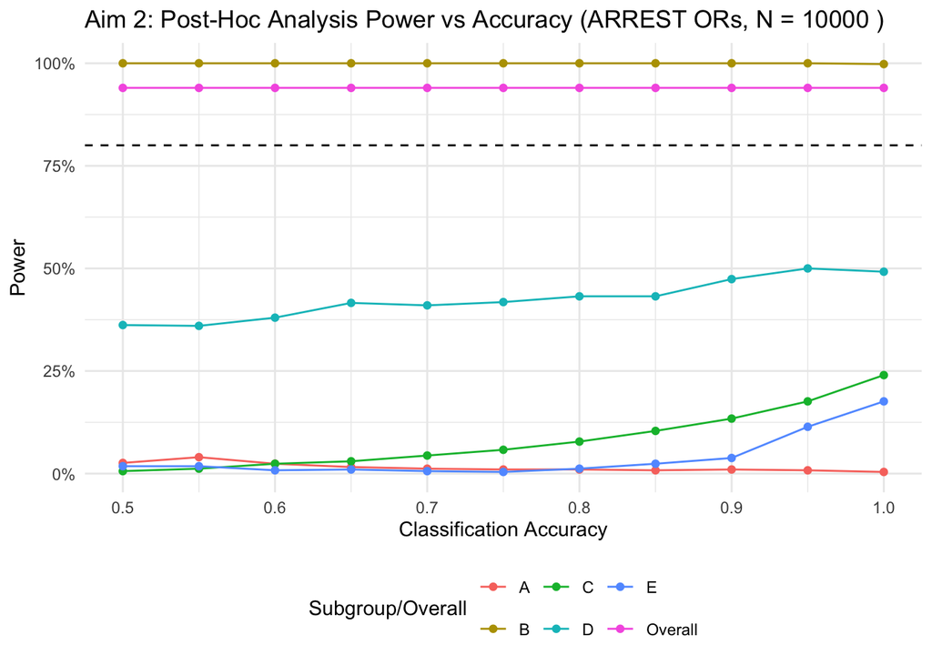

```r
ggplot(summary_aim2, aes(x = accuracy, y = power, color = group)) +
  geom_line() + geom_point() +
  geom_hline(yintercept = 0.8, linetype = "dashed") +
  scale_y_continuous(labels = scales::percent) +
  labs(
    title = paste("Aim 2: Post-Hoc Analysis Power vs Accuracy (ARREST ORs, N =", n_fixed_aim2, ")"),
    x     = "Classification Accuracy",
    y     = "Power",
    color = "Subgroup/Overall"
  )
```

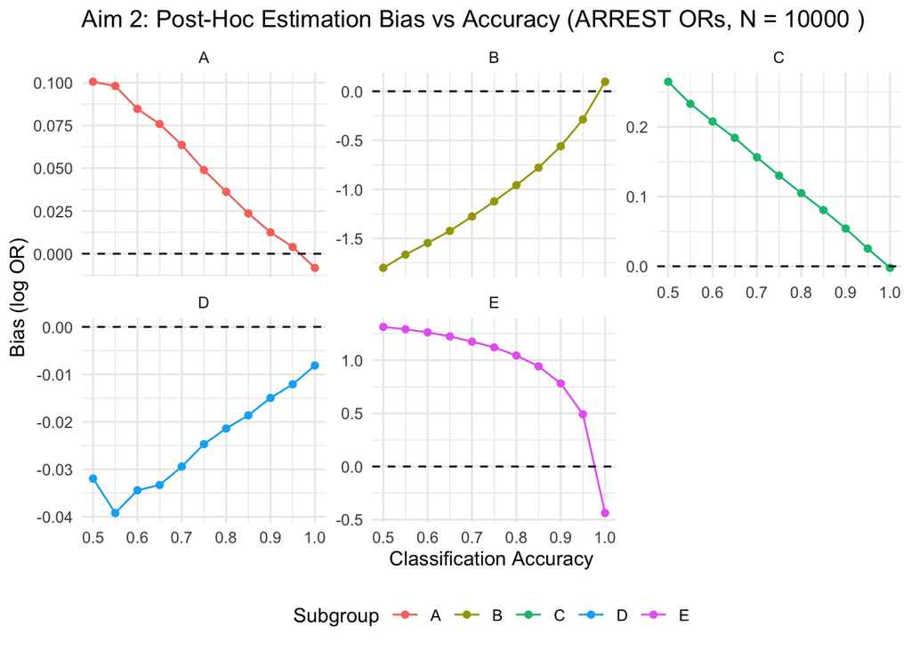

```r
# Filter out Overall group for this plot
ggplot(summary_aim2 %>% filter(group != "Overall"), aes(x = accuracy, y = bias, color = group)) +
  geom_line() + geom_point() +
  facet_wrap(~ group, scales = "free_y") +
  geom_hline(yintercept = 0, linetype = "dashed") +
  labs(
    title = paste("Aim 2: Post-Hoc Estimation Bias vs Accuracy (ARREST ORs, N =", n_fixed_aim2, ")"),
    x     = "Classification Accuracy",
    y     = "Bias (log OR)",
    color = "Subgroup"
  )
```

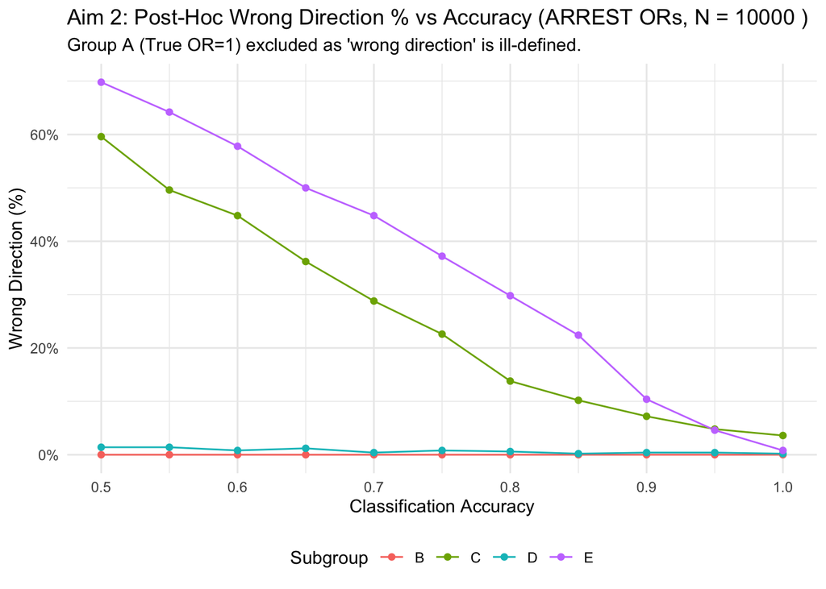

```r
# Filter out Overall and Group A for this plot
ggplot(summary_aim2 %>% filter(group != "Overall", group != "A"), aes(x = accuracy, y = wrong_dir, color = group)) +
  geom_line() + geom_point() +
  scale_y_continuous(labels = scales::percent_format(scale = 1)) +
  labs(
    title = paste("Aim 2: Post-Hoc Wrong Direction % vs Accuracy (ARREST ORs, N =", n_fixed_aim2, ")"),
    subtitle = "Group A (True OR=1) excluded as 'wrong direction' is ill-defined.",
    x     = "Classification Accuracy",
    y     = "Wrong Direction (%)",
    color = "Subgroup"
  )
```

[figure not shown]

### Aim 3: Sample Size Requirements (Enrichment Trial Simulation)

This section estimates the Number Needed to Screen (NNS) and the average resulting Number Needed to Randomize (NNR) to achieve 80% power in an **enrichment trial**, where recruitment is guided by a test with varying accuracy.

```r
# Function to run enrichment simulation replicates for one scenario
run_enrichment_scenario <- function(n_screened, target_group, accuracy,
                                    or_vector, p0_vector, freq_vector,
                                    n_reps, base_seed) {
  map_dfr(1:n_reps, ~{
    # Generate unique seed for this replicate
    seed <- base_seed + .x

    # 1. Simulate screened cohort
    screened_data <- simulate_trial_data(
      or_vector = or_vector,
      freq_vector = freq_vector,
      n = n_screened,
      p0_vector = p0_vector,
      seed = seed
    )
    # 2. Apply test (misclassify) using the SAME logic as Aim 2
    # Assumes misclassify_group function is available (defined in setup)
    tested_data <- misclassify_group(
        screened_data,
        accuracy = accuracy,
        freq_vector = freq_vector, # Pass named freq_vector
        seed = seed + n_reps # Use different seed offset for misclassification step
        )

    # 3. Select cohort for randomization ("test positives")
    randomized_cohort <- tested_data %>% filter(assigned_group == target_group)
    n_randomized_actual <- nrow(randomized_cohort)

    # 4. Analyze if cohort is large enough
    if(n_randomized_actual >= 10) { # Need minimum size for GLM
       analysis_results <- fit_glm_safe(randomized_cohort)
    } else {
       analysis_results <- tibble(beta = NA_real_, se = NA_real_, pval = NA_real_)
    }

    # Return results for this replicate
    tibble(
        n_randomized_actual = n_randomized_actual
        ) %>% bind_cols(analysis_results)

  }, .id = "rep")
}

# --- Run Aim 3 Simulations ---
# Define parameter grid for Aim 3
aim3_params <- expand_grid(
    target_group = target_groups_aim3,
    accuracy = accuracy_levels, # Use same accuracy levels as Aim 2
    n_screened = screen_sizes_aim3
)

# Setup parallel processing using future and furrr
# library(future) # Loaded in setup
# library(furrr)  # Loaded in setup
# Set up workers - use detectCores() - 1 for safety
n_cores <- parallel::detectCores() - 1
if (n_cores < 1) n_cores <- 1 # Ensure at least 1 core
plan(multisession, workers = n_cores)
# Optional: Increase max size for globals if needed (start without)
# options(future.globals.maxSize = 2 * 1024^3)

message(paste("Starting Aim 3 simulations using", n_cores, "cores..."))

# Use future_pmap_dfr for parallel execution
results_aim3 <- future_pmap_dfr(aim3_params, function(target_group, accuracy, n_screened) {
    # message(paste("Running Aim 3: Group", target_group, "Acc", accuracy, "N_screen", n_screened)) # Progress message per task
    run_enrichment_scenario(
        n_screened = n_screened,
        target_group = target_group,
        accuracy = accuracy,
        or_vector = or_mortality,
        p0_vector = p0_arrest_adjusted,
        freq_vector = freq_arrest,
        n_reps = n_reps_global,
        # Ensure unique base seed for each scenario combination
        base_seed = 3000 + which(aim3_params$target_group == target_group & aim3_params$accuracy == accuracy & aim3_params$n_screened == n_screened) * n_reps_global
        ) %>%
    mutate( # Add parameters back for grouping
        target_group = target_group,
        accuracy = accuracy,
        n_screened = n_screened
        )
}, .progress = TRUE, .options = furrr_options(seed = TRUE)) # Use progress bar and ensure seeds work in parallel

# Shut down parallel workers
plan(sequential)

message("Aim 3 simulations complete. Processing results...")

# --- Process Aim 3 Results ---
# Calculate power and average N randomized for each scenario
summary_aim3 <- results_aim3 %>%
  mutate(pval = as.numeric(pval)) %>%
  group_by(target_group, accuracy, n_screened) %>%
  summarise(
    power = mean(pval < alpha_aim3, na.rm = TRUE),
    mean_n_randomized = mean(n_randomized_actual, na.rm = TRUE),
    sd_n_randomized = sd(n_randomized_actual, na.rm = TRUE),
    n_reps_analyzed = sum(!is.na(pval)),
    .groups = "drop"
  )

# Find NNS required for 80% power
nns_enrich <- summary_aim3 %>%
  group_by(target_group, accuracy) %>%
  arrange(n_screened) %>%
  filter(power >= 0.8) %>%
  slice(1) %>% # First n_screened where power >= 0.8
  select(target_group, accuracy, nns_needed_num = n_screened) %>%
  ungroup() %>%
  # Ensure all combinations are present, even if power goal not met
  full_join(expand_grid(target_group = target_groups_aim3, accuracy = accuracy_levels), by = c("target_group", "accuracy")) %>%
  mutate(
    max_n_screened_aim3 = max(screen_sizes_aim3),
    `N Needed to Screen (NNS)` = if_else(
      is.na(nns_needed_num),
      paste(">", scales::comma(max_n_screened_aim3)),
      scales::comma(nns_needed_num)
    )
  ) %>%
  select(target_group, accuracy, `N Needed to Screen (NNS)`, nns_needed_num)

# Get the corresponding average NNR for the NNS found
nnr_enrich <- nns_enrich %>%
  # Join back to summary_aim3 only where NNS was determined
  left_join(summary_aim3 %>% select(target_group, accuracy, n_screened, mean_n_randomized),
            by = c("target_group", "accuracy", "nns_needed_num" = "n_screened")) %>%
  mutate(`NNR (Enrichment)` = if_else(
      is.na(mean_n_randomized), # Check if join failed (i.e., power not reached)
      "-",
      scales::comma(round(mean_n_randomized), accuracy = 1)
      )) %>%
  select(target_group, accuracy, `NNR (Enrichment)`)


# Combine NNS and NNR results
implications_enrichment <- nns_enrich %>%
    left_join(nnr_enrich, by = c("target_group", "accuracy")) %>%
    left_join(
        tibble(target_group = names(or_mortality), target_or = or_mortality) %>% filter(target_group %in% target_groups_aim3),
        by = "target_group"
    ) %>%
    select(
        Subgroup = target_group,
        `Target OR` = target_or,
        `Test Accuracy` = accuracy,
        `NNR (Enrichment)`,
        `N Needed to Screen (NNS)`
    ) %>%
    arrange(Subgroup, desc(`Test Accuracy`))
```

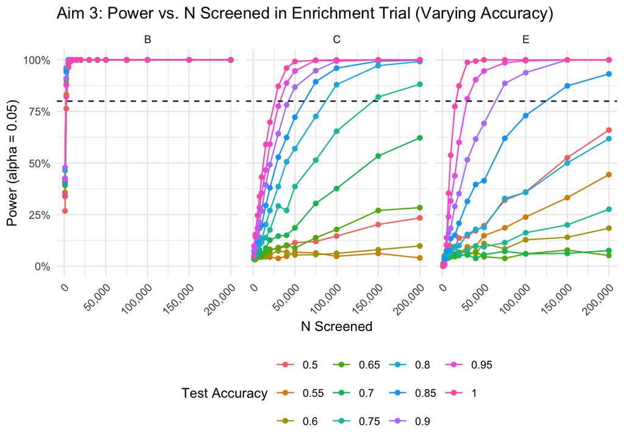

```r
# Plot power vs N Screened
ggplot(summary_aim3, aes(x = n_screened, y = power, color = factor(accuracy))) +
  geom_line() + geom_point() +
  geom_hline(yintercept = 0.8, linetype = "dashed") +
  facet_wrap(~ target_group, scales = "free_x") +
  scale_x_continuous(labels = scales::comma) + # Format x-axis
  scale_y_continuous(labels = scales::percent) +
  labs(
    title = "Aim 3: Power vs. N Screened in Enrichment Trial (Varying Accuracy)",
    x = "N Screened",
    y = "Power (alpha = 0.05)",
    color = "Test Accuracy"
  ) +
  theme(axis.text.x = element_text(angle = 45, hjust = 1))
```

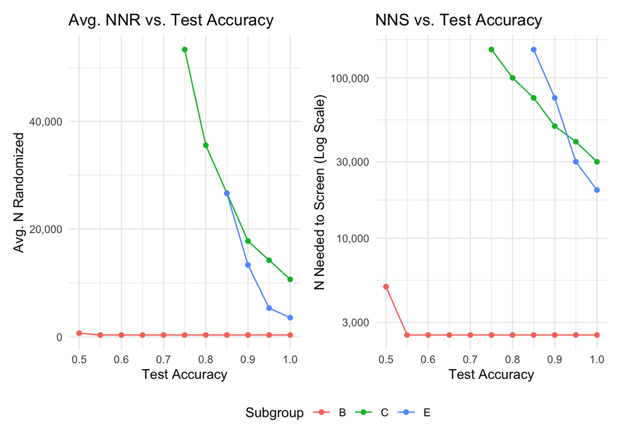

```r
# Plot NNR vs Accuracy
plot_nnr <- ggplot(implications_enrichment %>% filter(`NNR (Enrichment)` != "-"),
       aes(x = `Test Accuracy`, y = as.numeric(gsub(",", "", `NNR (Enrichment)`)), color = Subgroup)) +
  geom_line() + geom_point() +
  scale_y_continuous(labels = scales::comma) +
  labs(title = "Avg. NNR vs. Test Accuracy", x = "Test Accuracy", y = "Avg. N Randomized")

# Plot NNS vs Accuracy
plot_nns <- ggplot(implications_enrichment %>% filter(str_detect(`N Needed to Screen (NNS)`, "^>", negate=TRUE)), # Exclude ">" values for plotting
       aes(x = `Test Accuracy`, y = as.numeric(gsub(",", "", `N Needed to Screen (NNS)`)), color = Subgroup)) +
  geom_line() + geom_point() +
  scale_y_log10(labels = scales::comma) + # Use log scale for NNS
  labs(title = "NNS vs. Test Accuracy", x = "Test Accuracy", y = "N Needed to Screen (Log Scale)")

# Combine plots
plot_nnr + plot_nns + patchwork::plot_layout(guides = 'collect') & theme(legend.position = 'bottom')
```

## Supplementary: Realistic Effects

*(Note: Aim 3 simulation was only run for ARREST ORs. Equivalent simulations could be added here for realistic ORs if desired, following the same structure as Aim 3 above but using `or_realistic`.)*

```r
# Display target ORs for Realistic simulation
tibble(
  Subgroup = names(or_realistic),
  `Target OR (Mortality)` = or_realistic
) %>%
  gt() %>%
  tab_header(title = "Target Treatment Effects (Realistic ORs)") %>%
  fmt_number(columns = `Target OR (Mortality)`, decimals = 2)
```

Target Treatment Effects (Realistic ORs)

| Subgroup | Target OR (Mortality) |
| --- | --- |
| A | 1.00 |
| B | 2.00 |
| C | 0.70 |
| D | 1.20 |
| E | 0.80 |

### Supplementary Aim 1: Power vs. Sample Size (Realistic ORs)

```r
results_aim1_real <- map_dfr(sample_sizes, ~replicate_sims(
  or_vector   = or_realistic,
  freq_vector = freq_arrest,
  n           = .x,
  p0_vector   = p0_arrest_adjusted, # Using corrected p0 for B
  accuracy    = 1.0,
  n_reps      = n_reps_global,
  seed        = 4
), .id = "size_id") %>%
  mutate(n_total = sample_sizes[as.numeric(size_id)])

power_aim1_real <- results_aim1_real %>%
  filter(group != "Overall") %>%
  mutate(pval = as.numeric(pval)) %>%
  group_by(n_total, group) %>%
  summarise(power = mean(pval < alpha_bonferroni, na.rm = TRUE), .groups = "drop")
```

```r
power_aim1_real %>%
  mutate(power = scales::percent(power, accuracy = 1)) %>%
  pivot_wider(names_from = group, values_from = power) %>%
  gt() %>%
  cols_label(n_total = "Total Sample Size") %>%
  tab_header(title = "Supplementary: Power vs. Sample Size (Realistic ORs, Perfect Classification)") %>%
  tab_footnote(footnote = paste("Power calculated at Bonferroni-corrected alpha =", round(alpha_bonferroni, 3))) %>%
  fmt_percent(columns = where(is.character), scale_values = FALSE, decimals = 1)
```

Supplementary: Power vs. Sample Size (Realistic ORs, Perfect Classification)

| Total Sample Size | A | B | C | D | E |
| --- | --- | --- | --- | --- | --- |
| 500 | 0% | 0% | 0% | 1% | 0% |
| 1000 | 1% | 0% | 3% | 2% | 0% |
| 2000 | 0% | 0% | 8% | 3% | 0% |
| 3000 | 1% | 0% | 12% | 5% | 0% |
| 5000 | 1% | 0% | 25% | 7% | 0% |
| 7500 | 0% | 1% | 39% | 10% | 1% |
| 10000 | 0% | 6% | 53% | 13% | 0% |
| 15000 | 1% | 15% | 78% | 21% | 3% |
| 20000 | 1% | 24% | 87% | 29% | 2% |

Power calculated at Bonferroni-corrected alpha = 0.01

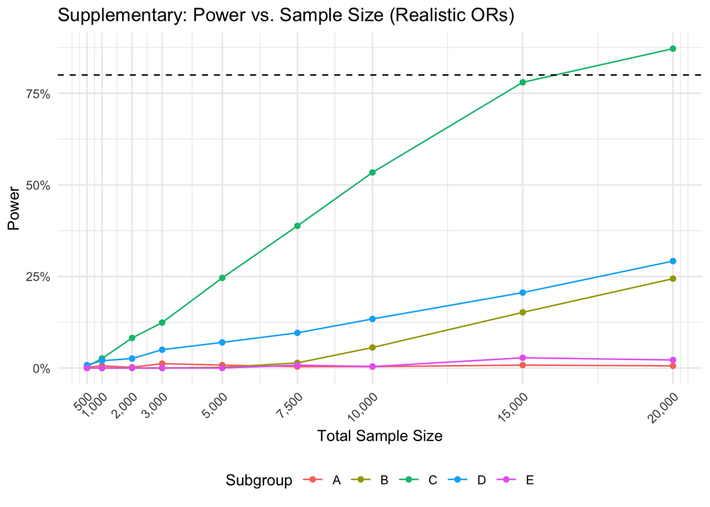

```r
ggplot(power_aim1_real, aes(x = n_total, y = power, color = group)) +
  geom_line() + geom_point() +
  geom_hline(yintercept = 0.8, linetype = "dashed") +
  scale_x_continuous(breaks = sample_sizes, labels = scales::comma) +
  scale_y_continuous(labels = scales::percent) +
  labs(
    title = "Supplementary: Power vs. Sample Size (Realistic ORs)",
    x     = "Total Sample Size",
    y     = "Power",
    color = "Subgroup"
  ) +
  theme(axis.text.x = element_text(angle = 45, hjust = 1))
```

### Supplementary Aim 2: Power vs. Accuracy (Realistic ORs)

```r
results_aim2_real <- map_dfr(accuracy_levels, ~replicate_sims(
  or_vector   = or_realistic,
  freq_vector = freq_arrest,
  n           = n_fixed_aim2,
  p0_vector   = p0_arrest_adjusted, # Using corrected p0 for B
  accuracy    = .x,
  n_reps      = n_reps_global,
  seed        = 5
), .id = "acc_id") %>%
  mutate(accuracy = accuracy_levels[as.numeric(acc_id)])

# Define and join correct target betas for realistic ORs
true_betas_realistic <- tibble(group = names(or_realistic), true_beta_target = log(or_realistic))
true_beta_overall_realistic <- sum(log(or_realistic) * freq_arrest, na.rm = TRUE)
true_betas_realistic <- bind_rows(true_betas_realistic, tibble(group="Overall", true_beta_target = true_beta_overall_realistic))

# Join target betas and calculate per-replicate metrics
results_aim2_real_processed <- results_aim2_real %>%
  mutate(beta = as.numeric(beta), pval = as.numeric(pval)) %>%
  left_join(true_betas_realistic, by = "group") %>%
  mutate(
    is_significant = if_else(group == "Overall", pval < alpha_overall, pval < alpha_bonferroni),
    bias_val = beta - true_beta_target,
    mse_val = (beta - true_beta_target)^2,
    wrong_dir_val = if_else(true_beta_target == 0, sign(beta) != 0, sign(beta) != sign(true_beta_target))
  )

# Summarise across replicates
summary_aim2_real <- results_aim2_real_processed %>%
  group_by(accuracy, group) %>%
  summarise(
    power     = mean(is_significant, na.rm = TRUE),
    bias      = mean(bias_val, na.rm = TRUE),
    mse       = mean(mse_val, na.rm = TRUE),
    wrong_dir = mean(wrong_dir_val, na.rm = TRUE) * 100,
    .groups   = "drop"
  ) %>%
  complete(accuracy, group = c("A", "B", "C", "D", "E", "Overall")) %>%
  arrange(group, accuracy)
```

```r
# Long format GT table for Aim 2 Realistic results
summary_aim2_real %>%
  select(
    group,
    accuracy,
    Power = power,
    Bias = bias,
    MSE = mse,
    `Wrong Dir %` = wrong_dir
  ) %>%
  gt(groupname_col = "group") %>%
  fmt_percent(columns = Power, decimals = 1) %>%
  fmt_number(columns = c(Bias, MSE), decimals = 2) %>%
  fmt_percent(columns = `Wrong Dir %`, scale_values = FALSE, decimals = 1) %>%
  fmt_number(columns = accuracy, decimals = 2) %>%
  cols_label(
    accuracy = "Accuracy",
    Power = "Power",
    Bias = "Bias",
    MSE = "MSE",
    `Wrong Dir %` = "Wrong Dir %"
  ) %>%
  tab_header(title = paste("Supplementary: Simulation Summary vs. Accuracy (Realistic ORs, N =", n_fixed_aim2, ")")) %>%
  tab_options(row_group.font.weight = "bold")
```

Supplementary: Simulation Summary vs. Accuracy (Realistic ORs, N = 10000 )

| Accuracy | Power | Bias | MSE | Wrong Dir % |
| --- | --- | --- | --- | --- |
| A |  |  |  |  |
| 0.50 | 0.2% | −0.03 | 0.03 | 100.0% |
| 0.55 | 1.6% | −0.02 | 0.03 | 100.0% |
| 0.60 | 0.4% | −0.02 | 0.03 | 100.0% |
| 0.65 | 0.4% | −0.01 | 0.03 | 100.0% |
| 0.70 | 0.6% | −0.01 | 0.03 | 100.0% |
| 0.75 | 0.6% | −0.01 | 0.03 | 100.0% |
| 0.80 | 0.4% | −0.01 | 0.03 | 100.0% |
| 0.85 | 0.4% | −0.01 | 0.03 | 100.0% |
| 0.90 | 0.4% | −0.01 | 0.03 | 100.0% |
| 0.95 | 0.6% | −0.01 | 0.03 | 100.0% |
| 1.00 | 0.4% | −0.01 | 0.03 | 100.0% |
| B |  |  |  |  |
| 0.50 | 0.8% | −0.63 | 0.47 | 39.8% |
| 0.55 | 0.8% | −0.59 | 0.43 | 32.4% |
| 0.60 | 0.6% | −0.57 | 0.40 | 29.6% |
| 0.65 | 0.6% | −0.55 | 0.38 | 29.2% |
| 0.70 | 1.0% | −0.50 | 0.35 | 24.0% |
| 0.75 | 1.4% | −0.45 | 0.31 | 22.4% |
| 0.80 | 1.6% | −0.41 | 0.28 | 18.8% |
| 0.85 | 2.0% | −0.36 | 0.26 | 17.6% |
| 0.90 | 3.8% | −0.28 | 0.25 | 15.4% |
| 0.95 | 3.0% | −0.16 | 0.22 | 11.2% |
| 1.00 | 5.6% | 0.06 | 0.84 | 7.6% |
| C |  |  |  |  |
| 0.50 | 13.2% | 0.16 | 0.04 | 6.0% |
| 0.55 | 19.2% | 0.14 | 0.04 | 6.0% |
| 0.60 | 22.4% | 0.13 | 0.04 | 4.4% |
| 0.65 | 28.0% | 0.11 | 0.03 | 3.8% |
| 0.70 | 30.6% | 0.09 | 0.03 | 2.8% |
| 0.75 | 34.0% | 0.08 | 0.03 | 2.4% |
| 0.80 | 37.2% | 0.06 | 0.02 | 1.6% |
| 0.85 | 40.2% | 0.05 | 0.02 | 1.4% |
| 0.90 | 43.2% | 0.03 | 0.02 | 1.0% |
| 0.95 | 48.4% | 0.01 | 0.02 | 0.6% |
| 1.00 | 53.6% | 0.00 | 0.02 | 0.6% |
| D |  |  |  |  |
| 0.50 | 3.6% | −0.07 | 0.03 | 23.8% |
| 0.55 | 2.4% | −0.08 | 0.03 | 23.2% |
| 0.60 | 4.6% | −0.07 | 0.03 | 21.4% |
| 0.65 | 5.2% | −0.06 | 0.02 | 19.6% |
| 0.70 | 6.6% | −0.05 | 0.02 | 17.4% |
| 0.75 | 7.8% | −0.04 | 0.02 | 16.2% |
| 0.80 | 8.8% | −0.03 | 0.02 | 14.6% |
| 0.85 | 8.8% | −0.03 | 0.02 | 11.6% |
| 0.90 | 10.8% | −0.02 | 0.02 | 11.4% |
| 0.95 | 11.8% | −0.01 | 0.02 | 9.8% |
| 1.00 | 13.4% | −0.01 | 0.02 | 9.2% |
| E |  |  |  |  |
| 0.50 | 1.4% | 0.15 | 0.08 | 37.8% |
| 0.55 | 0.8% | 0.16 | 0.08 | 39.6% |
| 0.60 | 0.6% | 0.16 | 0.09 | 40.4% |
| 0.65 | 0.6% | 0.15 | 0.09 | 39.2% |
| 0.70 | 0.4% | 0.14 | 0.09 | 38.8% |
| 0.75 | 0.6% | 0.14 | 0.10 | 39.0% |
| 0.80 | 1.0% | 0.12 | 0.11 | 37.2% |
| 0.85 | 0.8% | 0.11 | 0.12 | 37.4% |
| 0.90 | 1.2% | 0.09 | 0.13 | 36.2% |
| 0.95 | 0.6% | 0.05 | 0.15 | 31.6% |
| 1.00 | 0.4% | 0.00 | 0.19 | 27.8% |
| Overall |  |  |  |  |
| 0.50 | 10.4% | 0.00 | 0.01 | 27.4% |
| 0.55 | 10.4% | 0.00 | 0.01 | 27.4% |
| 0.60 | 10.4% | 0.00 | 0.01 | 27.4% |
| 0.65 | 10.4% | 0.00 | 0.01 | 27.4% |
| 0.70 | 10.4% | 0.00 | 0.01 | 27.4% |
| 0.75 | 10.4% | 0.00 | 0.01 | 27.4% |
| 0.80 | 10.4% | 0.00 | 0.01 | 27.4% |
| 0.85 | 10.4% | 0.00 | 0.01 | 27.4% |
| 0.90 | 10.4% | 0.00 | 0.01 | 27.4% |
| 0.95 | 10.4% | 0.00 | 0.01 | 27.4% |
| 1.00 | 10.4% | 0.00 | 0.01 | 27.4% |

[figure not shown]

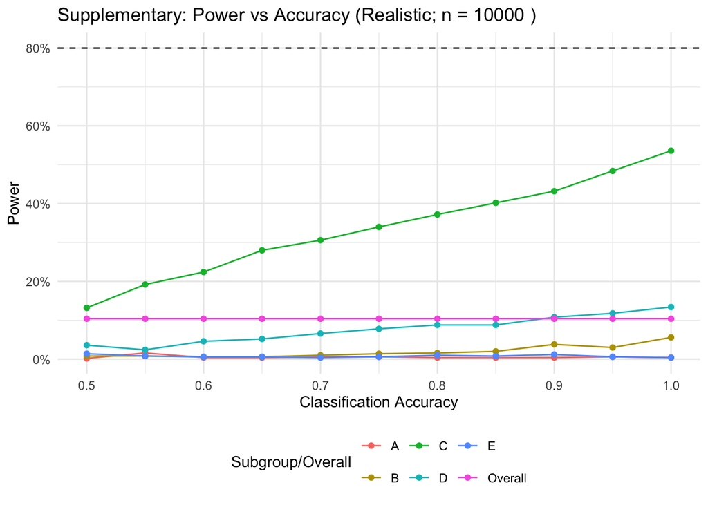

```r
ggplot(summary_aim2_real, aes(x = accuracy, y = power, color = group)) +
  geom_line() + geom_point() +
  geom_hline(yintercept = 0.8, linetype = "dashed") +
  scale_y_continuous(labels = scales::percent) +
  labs(
    title = paste("Supplementary: Power vs Accuracy (Realistic; n =", n_fixed_aim2, ")"),
    x     = "Classification Accuracy",
    y     = "Power",
    color = "Subgroup/Overall"
  )
```

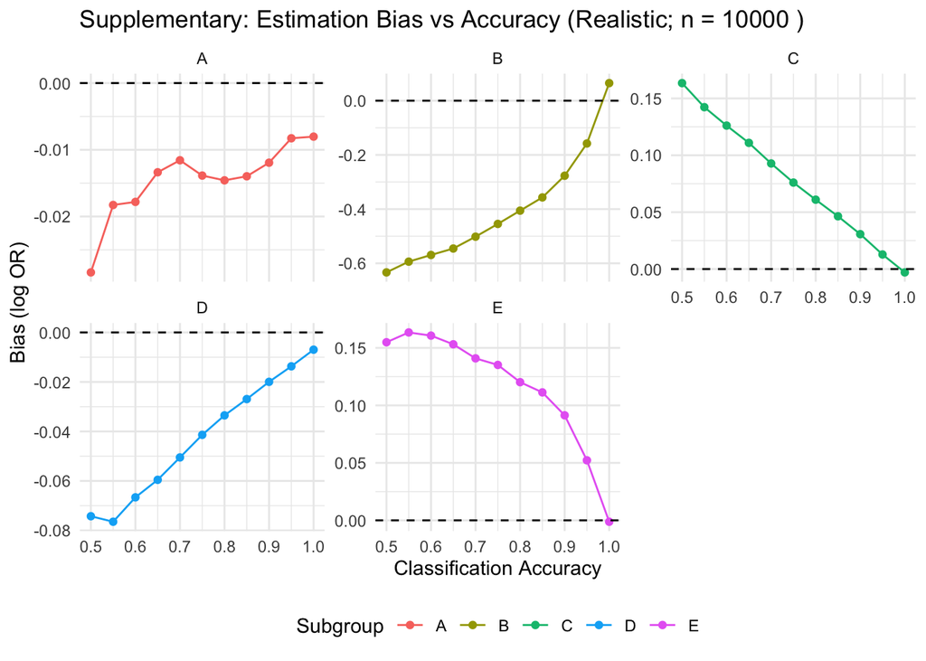

```r
# Filter out Overall group for this plot
ggplot(summary_aim2_real %>% filter(group != "Overall"), aes(x = accuracy, y = bias, color = group)) +
  geom_line() + geom_point() +
  facet_wrap(~ group, scales = "free_y") +
  geom_hline(yintercept = 0, linetype = "dashed") +
  labs(
    title = paste("Supplementary: Estimation Bias vs Accuracy (Realistic; n =", n_fixed_aim2, ")"),
    x     = "Classification Accuracy",
    y     = "Bias (log OR)",
    color = "Subgroup"
  )
```

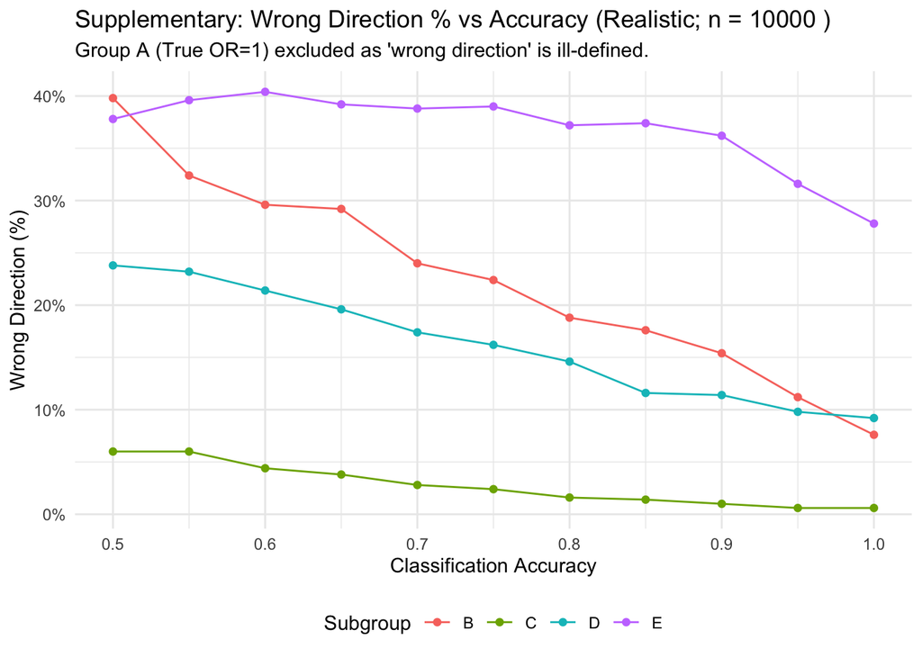

```r
# Filter out Overall and Group A for this plot
ggplot(summary_aim2_real %>% filter(group != "Overall", group != "A"), aes(x = accuracy, y = wrong_dir, color = group)) +
  geom_line() + geom_point() +
  scale_y_continuous(labels = scales::percent_format(scale = 1)) +
  labs(
    title = paste("Supplementary: Wrong Direction % vs Accuracy (Realistic; n =", n_fixed_aim2, ")"),
    subtitle = "Group A (True OR=1) excluded as 'wrong direction' is ill-defined.",
    x     = "Classification Accuracy",
    y     = "Wrong Direction (%)",
    color = "Subgroup"
  )
```

## Discussion

This simulation study demonstrates the significant challenges in detecting heterogeneous treatment effects in the presence of subgroup misclassification, using parameters derived from a real-world *S. aureus* bacteremia trial.

Aim 2 quantifies the detrimental impact of misclassification accuracy on these post-hoc analyses. As accuracy decreases, statistical power diminishes, bias in effect estimates increases (generally towards the null), and the probability of estimating effects in the wrong direction rises. This underscores the critical importance of highly accurate subgroup classification methods if relying on post-hoc analyses.

### Practical Implications: Enrichment Trials

Aim 3 simulates an **enrichment trial** design, where patients are screened using a test with a given `accuracy` (probability of correct classification), and only those testing positive for the target subgroup are randomized. This allows estimation of the Number Needed to Screen (NNS) and the average resulting Number Needed to Randomize (NNR<sub>Enrich</sub>) within the enriched cohort required to achieve 80% power.

Estimated Sample Sizes for Enrichment Trial (80% Power)

| Test Accuracy | Avg. NNR | NNS |
| --- | --- | --- |
| B - 18.80 |  |  |
| 1.00 | 334 | 2,500 |
| 0.95 | 335 | 2,500 |
| 0.90 | 335 | 2,500 |
| 0.85 | 333 | 2,500 |
| 0.80 | 334 | 2,500 |
| 0.75 | 335 | 2,500 |
| 0.70 | 333 | 2,500 |
| 0.65 | 334 | 2,500 |
| 0.60 | 334 | 2,500 |
| 0.55 | 333 | 2,500 |
| 0.50 | 672 | 5,000 |
| C - 0.79 |  |  |
| 1.00 | 10,667 | 30,000 |
| 0.95 | 14,224 | 40,000 |
| 0.90 | 17,791 | 50,000 |
| 0.85 | 26,682 | 75,000 |
| 0.80 | 35,575 | 100,000 |
| 0.75 | 53,364 | 150,000 |
| 0.70 | - | > 200,000 |
| 0.65 | - | > 200,000 |
| 0.60 | - | > 200,000 |
| 0.55 | - | > 200,000 |
| 0.50 | - | > 200,000 |
| E - 0.30 |  |  |
| 1.00 | 3,555 | 20,000 |
| 0.95 | 5,337 | 30,000 |
| 0.90 | 13,337 | 75,000 |
| 0.85 | 26,662 | 150,000 |
| 0.80 | - | > 200,000 |
| 0.75 | - | > 200,000 |
| 0.70 | - | > 200,000 |
| 0.65 | - | > 200,000 |
| 0.60 | - | > 200,000 |
| 0.55 | - | > 200,000 |
| 0.50 | - | > 200,000 |

NNR (Enrichment): Average number needed to randomize *within the enriched cohort* (those testing positive) to achieve 80% power (alpha=0.05), based on test accuracy (from Aim 3). NNS: Number needed to screen in the general population to achieve 80% power.

The table shows the estimated NNS and resulting average NNR for enrichment trials targeting subgroups B, C, and E, based on the accuracy of the test used for screening. For example, the table indicates the approximate NNS and corresponding average NNR required to achieve 80% power for subgroup B using a test with 90% accuracy. As test accuracy decreases, both the required NNS and the average NNR increase substantially, highlighting the critical impact of test performance on the feasibility and efficiency of enrichment designs. The NNR increases with lower accuracy because the enriched cohort becomes more diluted with false positives, weakening the observed treatment effect, while the NNS increases even more dramatically as fewer true positives are correctly identified among the larger number screened.

## Conclusion

This simulation study demonstrates that accurate subgroup classification is paramount for reliably detecting heterogeneous treatment effects in *S. aureus* bacteremia. Post-hoc subgroup analyses require large sample sizes and are highly sensitive to misclassification accuracy. Enrichment trial designs can potentially reduce the number of patients randomized but require careful consideration of subgroup prevalence, effect size, baseline risk, and the performance characteristics of the classification test, as lower accuracy dramatically increases both the screening burden (NNS) and the number of patients needed within the enriched cohort (NNR).